# Zadanie domowe - EDA Danych dotyczących Irysów

- Twoim zadaniem jest wykonanie analizy danych zawartych w załączonym pliku CSV (`25__iris.csv`).
- Plik znajduje się pod video. Pamiętaj, żeby wrzucić plik do tego samego folderu, w którym znajduje się ten notebook.
- Wykorzystaj nowo nabytą wiedzę z biblioteki `Pandas`
- Jeżeli jest taka konieczność posiłkuj się [code explainerem](https://codeexplainer.imprv.ai/) lub / i [data chatterem](https://datachatter.imprv.ai/) (który również te dane ma dostępne).
- Prześlij na discordzie notebook z rozwiązaniem (`#modul-4-zad1`)
- Pamiętaj:
1. Nie spiesz się
2. Potraktuj zadanie domowe jak prawdziwy projekt
3. Dodawaj opisy, obserwacje, wnioski
4. Dodaj wizualizacje
5. Dodaj konkluzję i wnioski końcowe

Powodzenia!!! I mega zabawy!

## O Danych

Zbiór danych zawiera informacje o trzech gatunkach irysów: Iris setosa, Iris versicolor, i Iris virginica.

Dane obejmują pomiary czterech cech: długość i szerokość działki kielicha oraz długość i szerokość płatka.

Każdy wiersz w zbiorze danych reprezentuje pojedynczy kwiat, a wartości pomiarów są podane w centymetrach.

Zbiór składa się z 150 próbek, po 50 dla każdego gatunku, i jest szeroko stosowany jako podstawowy zbiór danych do testowania algorytmów klasyfikacji oraz w nauce o danych i uczeniu maszynowym.

Kolumny:

- **długość kielicha (sepal length)** - Długość kielicha w cm
- **szerokość kielicha (sepal width)** - Szerokość kielicha w cm
- **długość płatka (petal length)** - Długość płatka w cm
- **szerokość płatka (petal width)** - Szerokość płatka w cm
- **klasa (class)** - Klasa irysa (setosa, versicolor, virginica)

```python
import pandas as pd
pd.set_option('display.max_rows', None)
```

```python
df = pd.read_csv('25__iris.csv', sep=",")
df
```

|  | długość kielicha (sepal length) | szerokość kielicha (sepal width) | długość płatka (petal length) | szerokość płatka (petal width) | klasa (class) |
| --- | --- | --- | --- | --- | --- |
| 0 | 5.1 | 3.5 | 1.4 | 0.2 | Iris-setosa |
| 1 | 4.9 | 3.0 | 1.4 | 0.2 | Iris-setosa |
| 2 | 4.7 | 3.2 | 1.3 | 0.2 | Iris-setosa |
| 3 | 4.6 | 3.1 | 1.5 | 0.2 | Iris-setosa |
| 4 | 5.0 | 3.6 | 1.4 | 0.2 | Iris-setosa |
| 5 | 5.4 | 3.9 | 1.7 | 0.4 | Iris-setosa |
| 6 | 4.6 | 3.4 | 1.4 | 0.3 | Iris-setosa |
| 7 | 5.0 | 3.4 | 1.5 | 0.2 | Iris-setosa |
| 8 | 4.4 | 2.9 | 1.4 | 0.2 | Iris-setosa |
| 9 | 4.9 | 3.1 | 1.5 | 0.1 | Iris-setosa |
| 10 | 5.4 | 3.7 | 1.5 | 0.2 | Iris-setosa |
| 11 | 4.8 | 3.4 | 1.6 | 0.2 | Iris-setosa |
| 12 | 4.8 | 3.0 | 1.4 | 0.1 | Iris-setosa |
| 13 | 4.3 | 3.0 | 1.1 | 0.1 | Iris-setosa |
| 14 | 5.8 | 4.0 | 1.2 | 0.2 | Iris-setosa |
| 15 | 5.7 | 4.4 | 1.5 | 0.4 | Iris-setosa |
| 16 | 5.4 | 3.9 | 1.3 | 0.4 | Iris-setosa |
| 17 | 5.1 | 3.5 | 1.4 | 0.3 | Iris-setosa |
| 18 | 5.7 | 3.8 | 1.7 | 0.3 | Iris-setosa |
| 19 | 5.1 | 3.8 | 1.5 | 0.3 | Iris-setosa |
| 20 | 5.4 | 3.4 | 1.7 | 0.2 | Iris-setosa |
| 21 | 5.1 | 3.7 | 1.5 | 0.4 | Iris-setosa |
| 22 | 4.6 | 3.6 | 1.0 | 0.2 | Iris-setosa |
| 23 | 5.1 | 3.3 | 1.7 | 0.5 | Iris-setosa |
| 24 | 4.8 | 3.4 | 1.9 | 0.2 | Iris-setosa |
| 25 | 5.0 | 3.0 | 1.6 | 0.2 | Iris-setosa |
| 26 | 5.0 | 3.4 | 1.6 | 0.4 | Iris-setosa |
| 27 | 5.2 | 3.5 | 1.5 | 0.2 | Iris-setosa |
| 28 | 5.2 | 3.4 | 1.4 | 0.2 | Iris-setosa |
| 29 | 4.7 | 3.2 | 1.6 | 0.2 | Iris-setosa |

[output cut: 120 more lines]

# **Ogólny przegląd danych**

```python
# Informacje o DataFrame
df.info()
```

```
<class 'pandas.core.frame.DataFrame'>
RangeIndex: 150 entries, 0 to 149
Data columns (total 5 columns):
 #   Column                            Non-Null Count  Dtype
---  ------                            --------------  -----
 0   długość kielicha (sepal length)   150 non-null    float64
 1   szerokość kielicha (sepal width)  150 non-null    float64
 2   długość płatka (petal length)     150 non-null    float64
 3   szerokość płatka (petal width)    150 non-null    float64
 4   klasa (class)                     150 non-null    object
dtypes: float64(4), object(1)
memory usage: 6.0+ KB
```

```python
# Prezentacja 10 losowych rekordów
df.sample(10)
```

|  | długość kielicha (sepal length) | szerokość kielicha (sepal width) | długość płatka (petal length) | szerokość płatka (petal width) | klasa (class) |
| --- | --- | --- | --- | --- | --- |
| 70 | 5.9 | 3.2 | 4.8 | 1.8 | Iris-versicolor |
| 4 | 5.0 | 3.6 | 1.4 | 0.2 | Iris-setosa |
| 101 | 5.8 | 2.7 | 5.1 | 1.9 | Iris-virginica |
| 122 | 7.7 | 2.8 | 6.7 | 2.0 | Iris-virginica |
| 108 | 6.7 | 2.5 | 5.8 | 1.8 | Iris-virginica |
| 141 | 6.9 | 3.1 | 5.1 | 2.3 | Iris-virginica |
| 44 | 5.1 | 3.8 | 1.9 | 0.4 | Iris-setosa |
| 61 | 5.9 | 3.0 | 4.2 | 1.5 | Iris-versicolor |
| 27 | 5.2 | 3.5 | 1.5 | 0.2 | Iris-setosa |
| 91 | 6.1 | 3.0 | 4.6 | 1.4 | Iris-versicolor |

```python
# Informacje o ułożeniu danych w DataFrame na podstawie 10 pierwszych rekordów
df.head(10)
```

|  | długość kielicha (sepal length) | szerokość kielicha (sepal width) | długość płatka (petal length) | szerokość płatka (petal width) | klasa (class) |
| --- | --- | --- | --- | --- | --- |
| 0 | 5.1 | 3.5 | 1.4 | 0.2 | Iris-setosa |
| 1 | 4.9 | 3.0 | 1.4 | 0.2 | Iris-setosa |
| 2 | 4.7 | 3.2 | 1.3 | 0.2 | Iris-setosa |
| 3 | 4.6 | 3.1 | 1.5 | 0.2 | Iris-setosa |
| 4 | 5.0 | 3.6 | 1.4 | 0.2 | Iris-setosa |
| 5 | 5.4 | 3.9 | 1.7 | 0.4 | Iris-setosa |
| 6 | 4.6 | 3.4 | 1.4 | 0.3 | Iris-setosa |
| 7 | 5.0 | 3.4 | 1.5 | 0.2 | Iris-setosa |
| 8 | 4.4 | 2.9 | 1.4 | 0.2 | Iris-setosa |
| 9 | 4.9 | 3.1 | 1.5 | 0.1 | Iris-setosa |

```python
# Informacje o ułożeniu danych w DataFrame na podstawie 10 ostatnich rekordów
df.tail(10)
```

|  | długość kielicha (sepal length) | szerokość kielicha (sepal width) | długość płatka (petal length) | szerokość płatka (petal width) | klasa (class) |
| --- | --- | --- | --- | --- | --- |
| 140 | 6.7 | 3.1 | 5.6 | 2.4 | Iris-virginica |
| 141 | 6.9 | 3.1 | 5.1 | 2.3 | Iris-virginica |
| 142 | 5.8 | 2.7 | 5.1 | 1.9 | Iris-virginica |
| 143 | 6.8 | 3.2 | 5.9 | 2.3 | Iris-virginica |
| 144 | 6.7 | 3.3 | 5.7 | 2.5 | Iris-virginica |
| 145 | 6.7 | 3.0 | 5.2 | 2.3 | Iris-virginica |
| 146 | 6.3 | 2.5 | 5.0 | 1.9 | Iris-virginica |
| 147 | 6.5 | 3.0 | 5.2 | 2.0 | Iris-virginica |
| 148 | 6.2 | 3.4 | 5.4 | 2.3 | Iris-virginica |
| 149 | 5.9 | 3.0 | 5.1 | 1.8 | Iris-virginica |

```python
# Informacje o wartościach unikatowych dla danych nienumerycznych
df["klasa (class)"].unique()
```

```
array(['Iris-setosa', 'Iris-versicolor', 'Iris-virginica'], dtype=object)
```

```python
# Informacje o liczbie wartości unikatowych dla danych nienumerycznych
df["klasa (class)"].value_counts()
```

```
Iris-setosa        50
Iris-versicolor    50
Iris-virginica     50
Name: klasa (class), dtype: int64
```

```python
# Podsumowanie każdej kolumny numerycznej
df.describe()
```

|  | długość kielicha (sepal length) | szerokość kielicha (sepal width) | długość płatka (petal length) | szerokość płatka (petal width) |
| --- | --- | --- | --- | --- |
| count | 150.000000 | 150.000000 | 150.000000 | 150.000000 |
| mean | 5.843333 | 3.054000 | 3.758667 | 1.198667 |
| std | 0.828066 | 0.433594 | 1.764420 | 0.763161 |
| min | 4.300000 | 2.000000 | 1.000000 | 0.100000 |
| 25% | 5.100000 | 2.800000 | 1.600000 | 0.300000 |
| 50% | 5.800000 | 3.000000 | 4.350000 | 1.300000 |
| 75% | 6.400000 | 3.300000 | 5.100000 | 1.800000 |
| max | 7.900000 | 4.400000 | 6.900000 | 2.500000 |

# **Analiza brakujących wartości**

```python
# Informacje o wartościach brakujących w każdej kolumnie
df.isnull().sum()
```

```
długość kielicha (sepal length)     0
szerokość kielicha (sepal width)    0
długość płatka (petal length)       0
szerokość płatka (petal width)      0
klasa (class)                       0
dtype: int64
```

```python
# Informacje o typach danych dla każdej seri danych
df.dtypes
```

```
długość kielicha (sepal length)     float64
szerokość kielicha (sepal width)    float64
długość płatka (petal length)       float64
szerokość płatka (petal width)      float64
klasa (class)                        object
dtype: object
```

**Wnioski** Zbiór danych jest kompletny, tj. nie wykazano brakujących wartości w seriach danych. Typ danych dla czterech serii danych to float. Seria danych 'klasa (class)' jest typu 'object', w tym przypadktu to dane typu 'string'.

# **Analiza pojedynczych zmiennych**

## Analiza serii danych

```
count    150.000000
mean       5.843333
std        0.828066
min        4.300000
25%        5.100000
50%        5.800000
75%        6.400000
max        7.900000
Name: długość kielicha (sepal length), dtype: float64
```

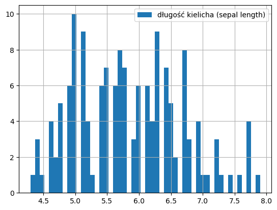

```python
df["długość kielicha (sepal length)"].hist(bins=50, legend=True)
df["długość kielicha (sepal length)"].describe()
```

**Wnioski cząstkowe dla serii danych 'długość kielicha (sepal length)'**

- **kształt rozkładu:** Rozkład danych jest prawie symetryczny, co oznacza, że większość wartości skupiona jest wokół średniej, a wartości ekstremalne występują mniej więcej równomiernie po obu stronach średniej. Regularnie występujące luki w pomiarach mogą wskazywać na istnienie kilku podgrup danych.
- **wartości centralne:** Niewielkie odchylenie między średnią (5.84) a medianą (5.80) wskazuje na możliwość relatywnie niewielkiego wystąpienia wartości odstających.
- **rozproszenie danych:** Rozproszenie danych jest umiarkowane. Odchylenie standardowe nie jest zbyt duże, co oznacza, że większość wartości skupiona jest blisko średniej. Rozstęp międzykwartylowy również wskazuje na umiarkowane rozproszenie.

```
count    150.000000
mean       3.054000
std        0.433594
min        2.000000
25%        2.800000
50%        3.000000
75%        3.300000
max        4.400000
Name: szerokość kielicha (sepal width), dtype: float64
```

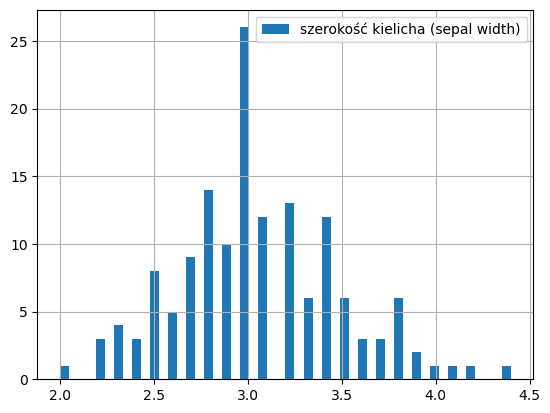

```python
df["szerokość kielicha (sepal width)"].hist(bins=50, legend=True)
df["szerokość kielicha (sepal width)"].describe()
```

**Wnioski cząstkowe dla serii danych 'szerokość kielicha (sepal width)'**

- **kształt rozkładu:** Rozkład danych jest prawie symetryczny, co oznacza, że większość wartości skupiona jest wokół średniej, a wartości ekstremalne występują mniej więcej równomiernie po obu stronach średniej.
- **wartości centralne:** Obie miary centralne są do siebie bardzo zbliżone, co ponownie potwierdza symetrię rozkładu. Oznacza to, że większość wartości skupia się wokół 3.
- **rozproszenie danych:** Odchylenie standardowe (std): 0.433594 i rozstęp kwartylowy (Q3-Q1): 0.5 wskazują na umiarkowane rozproszenie danych. Większość obserwacji znajduje się w stosunkowo wąskim przedziale wokół średniej.

```
count    150.000000
mean       3.758667
std        1.764420
min        1.000000
25%        1.600000
50%        4.350000
75%        5.100000
max        6.900000
Name: długość płatka (petal length), dtype: float64
```

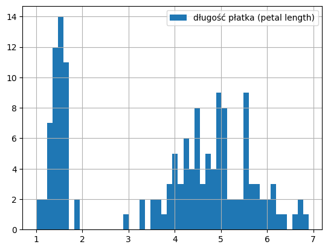

```python
df["długość płatka (petal length)"].hist(bins=50, legend=True)
df["długość płatka (petal length)"].describe()
```

```
count    150.000000
mean       1.198667
std        0.763161
min        0.100000
25%        0.300000
50%        1.300000
75%        1.800000
max        2.500000
Name: szerokość płatka (petal width), dtype: float64
```

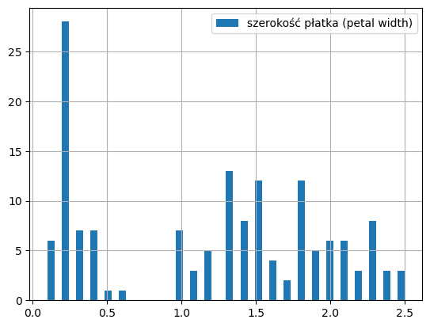

```python
df["szerokość płatka (petal width)"].hist(bins=50, legend=True)
df["szerokość płatka (petal width)"].describe()
```

## Analiza danych wg kategorii

### Kategoria 'Iris-setosa'

```python
Iris_setosa_df = df[df["klasa (class)"] == "Iris-setosa"]
```

```
count    50.00000
mean      5.00600
std       0.35249
min       4.30000
25%       4.80000
50%       5.00000
75%       5.20000
max       5.80000
Name: długość kielicha (sepal length), dtype: float64
```

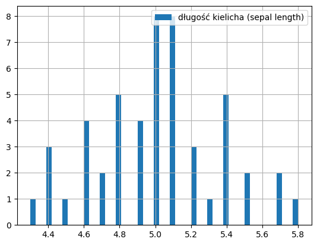

```python
Iris_setosa_df["długość kielicha (sepal length)"].hist(bins=50, legend=True)
Iris_setosa_df["długość kielicha (sepal length)"].describe()
```

**Wnioski cząstkowe dla serii danych 'długość kielicha (sepal length)'**

- **kształt rozkładu:** Symetryczny kształt rozkładu sugeruje, że dane są rozłożone równomiernie wokół wartości centralnych. Nie ma wyraźnej tendencji do skupiania się wartości po jednej ze stron średniej.
- **wartości centralne:** Równość średniej (5,00) i mediany (5,00) jest dodatkowym potwierdzeniem symetrii rozkładu. Oznacza to, że wartość środkowa zbioru danych (mediana) pokrywa się z wartością średnią arytmetyczną, co jest charakterystyczne dla rozkładów symetrycznych. Rozkład dwumodalny oznacza to, że dane skupiają się wokół dwóch różnych wartości, sugerując, że w badanej populacji istnieją dwie (lub więcej) odrębne grupy.
- **rozproszenie danych** Wąski zakres danych (min 4,30 / max 5,80) wskazuje, że wartości są dość zbliżone do siebie. Oznacza to, że większość obserwacji skupia się wokół wartości centralnych. Niskie odchylenie standardowe (std 0,35) potwierdza, że dane są mało zróżnicowane. Większość wartości znajduje się blisko średniej. Występuje jedna luka w wartościach.

```
count    50.000000
mean      3.418000
std       0.381024
min       2.300000
25%       3.125000
50%       3.400000
75%       3.675000
max       4.400000
Name: szerokość kielicha (sepal width), dtype: float64
```

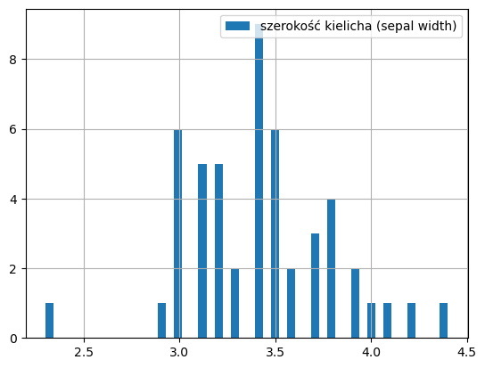

```python
Iris_setosa_df["szerokość kielicha (sepal width)"].hist(bins=50, legend=True)
Iris_setosa_df["szerokość kielicha (sepal width)"].describe()
```

**Wnioski cząstkowe dla serii danych 'szerokość kielicha (sepal width)'**

- **kształt rozkładu:** Symetryczny kształt rozkładu sugeruje, że dane są rozłożone dość równomiernie wokół wartości centralnych. Nie ma wyraźnej tendencji do skupiania się wartości po jednej ze stron średniej.
- **wartości centralne:** Choć występuje niewielkie odchylenie między średnią a medianą, jest ono bardzo małe (0,01). To sugeruje, że rozkład jest bliski symetrycznemu i nie ma znaczących asymetrii. Rozkład jednomodalny oznacza to, że najczęściej występującą wartością jest tylko jedna.
- **rozproszenie danych** Zakres danych (min 2,30 / max 4,40) oraz odchylenie standardowe (std 0,38) wskazują na średnie rozproszenie wartości. Oznacza to, że wartości są dość zróżnicowane, ale nie w sposób ekstremalny. Większość obserwacji skupia się wokół średniej, jednak występują również wartości bardziej oddalone. Występują luki w wartościach.

```
count    50.000000
mean      1.464000
std       0.173511
min       1.000000
25%       1.400000
50%       1.500000
75%       1.575000
max       1.900000
Name: długość płatka (petal length), dtype: float64
```

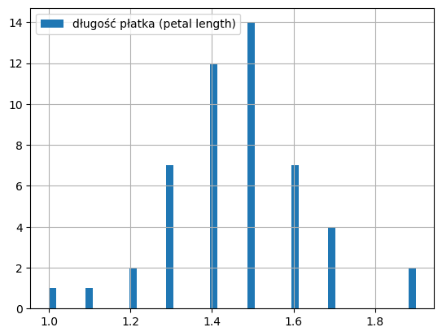

```python
Iris_setosa_df["długość płatka (petal length)"].hist(bins=50, legend=True)
Iris_setosa_df["długość płatka (petal length)"].describe()
```

**Wnioski cząstkowe dla serii danych 'długość płatka (petal length)'**

- **kształt rozkładu:** Symetryczny kształt rozkładu sugeruje, że dane są rozłożone dość równomiernie wokół wartości centralnych. Nie ma wyraźnej tendencji do skupiania się wartości po jednej ze stron średniej.
- **wartości centralne:** Choć występuje niewielkie odchylenie między średnią a medianą, jest ono bardzo małe (0,04). To sugeruje, że rozkład jest bliski symetrycznemu i nie ma znaczących asymetrii. Rozkład jednomodalny oznacza to, że najczęściej występującą wartością jest tylko jedna.
- **rozproszenie danych** Niewielki zakres danych (min 1,00 / max 1,90) oraz odchylenie standardowe (std 0,17) wskazują na niskie rozproszenie wartości. Oznacza to, że wartości są dość zbliżone do siebie i skupione wokół wartości centralnych. Występuje jedna luka w wartościach.

```
count    50.00000
mean      0.24400
std       0.10721
min       0.10000
25%       0.20000
50%       0.20000
75%       0.30000
max       0.60000
Name: szerokość płatka (petal width), dtype: float64
```

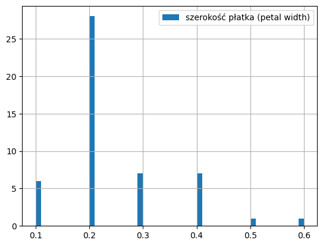

```python
Iris_setosa_df["szerokość płatka (petal width)"].hist(bins=50, legend=True)
Iris_setosa_df["szerokość płatka (petal width)"].describe()
```

**Wnioski cząstkowe dla serii danych 'szerokość płatka (petal width)'**

- **kształt rozkładu:** Fakt, że rozkład jest skośny prawostronnie oznacza, że większość wartości skupiona jest w lewej części rozkładu, a "ogon" rozciąga się w prawo. Innymi słowy, występuje więcej niskich wartości niż wysokich, a kilka wyjątkowo wysokich wartości wpływa na średnią, przesuwając ją w prawo w stosunku do mediany.
- **wartości centralne:** Różnica między średnią (0,24) a medianą (0,20) potwierdza skośność prawostronną. Średnia, która jest bardziej wrażliwa na wartości odstające, jest przesunięta w prawo w stosunku do mediany, która jest bardziej odporna na takie wartości. Rozkład jednomodalny oznacza to, że najczęściej występującą wartością jest tylko jedna.
- **rozproszenie danych** Zakres danych (min 0,1 / max 0,6) i odchylenie standardowe (std 0,11) wskazują na średnie rozproszenie wartości. Oznacza to, że wartości są dość zróżnicowane, ale nie w sposób ekstremalny. Większość obserwacji skupia się wokół wartości centralnych, jednak występują również wartości bardziej oddalone. Brak luk w wartościach.

**Wnioski z analizy kategorii 'Iris-setosa'**

- 'układ rozkładu' dla 3 na 4 zmiennych przyjmuje kształt symetrycznylub zbliżony do niego, co oznacza, że nie ma lub występują sporadycznie wartości, które znacząco odbiegają od większości danych.
- 'wartości centralne' dla 3 na 4 zmiennych nie notują znaczących odchyleń, co oznacza, że dane są dość jednorodne i skupione wokół pewnej centralnej wartości. Innymi słowy, większość obserwacji jest zbliżona do średniej, mediany lub mody.
- 'rozproszenie danych' dla 3 na 4 zmiennych wskazują na niski współczynnik rozporszenia, co oznacza, że dane w zbiorze są dość jednorodne i skupione wokół pewnej wartości centralnej.
- w 3 na 4 zmiennych występują luki w wartościach, w tym w 2 zmiennych są to braki pojedynczych wartości

*Uwaga - Z racji na fakt iż w 'kształcie rozkładu', 'wartościach centralne' i 'rozproszeniu danych' nie wystąpują znaczące anomalie należy przyjąć, że dane w zbiorze są poprawne. Przyczyną występujących braków wartości nie może być ograniczenia skali pomiarowej, gdyż braki występują w skalach większych. Jedynym tłumaczeniem przyczyny wystąpienia braków jest specyfika badanej populacji.*

```python
print("\033[1mCharakterystyka przedmiotu analizy\033[0m")
Iris_setosa_df[["długość kielicha (sepal length)", "szerokość kielicha (sepal width)", "długość płatka (petal length)", "szerokość płatka (petal width)"]].agg(["min", "max", "median"])
```

```
Charakterystyka przedmiotu analizy
```

|  | długość kielicha (sepal length) | szerokość kielicha (sepal width) | długość płatka (petal length) | szerokość płatka (petal width) |
| --- | --- | --- | --- | --- |
| min | 4.3 | 2.3 | 1.0 | 0.1 |
| max | 5.8 | 4.4 | 1.9 | 0.6 |
| median | 5.0 | 3.4 | 1.5 | 0.2 |

### Kategoria 'Iris-versicolor'

```python
Iris_versicolor_df = df[df["klasa (class)"] == "Iris-versicolor"]
```

```
count    50.000000
mean      5.936000
std       0.516171
min       4.900000
25%       5.600000
50%       5.900000
75%       6.300000
max       7.000000
Name: długość kielicha (sepal length), dtype: float64
```

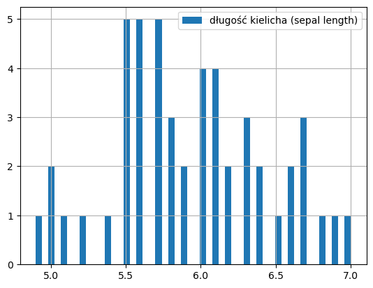

```python
Iris_versicolor_df["długość kielicha (sepal length)"].hist(bins=50, legend=True)
Iris_versicolor_df["długość kielicha (sepal length)"].describe()
```

**Wnioski cząstkowe dla serii danych 'długość kielicha (sepal length)'**

- **kształt rozkładu:** Rozkład jest zbliżony do symetrycznego. Na podstawie podanych kwartyli możemy wnioskować o symetrii rozkładu, gdzie różnica między medianą a pierwszym kwartylem: 5.9 - 5.6 = 0.3 a różnica między trzecim kwartylem a medianą: 6.3 - 5.9 = 0.4
- **wartości centralne:** Wartości średniej arytmetycznej (5.93) i mediany (5.90) są bardzo zbliżone, co potwierdza symetrię rozkładu. Oznacza to, że większość obserwacji skupia się wokół wartości 5.9. Rozkład multimodalny sugeruje, że w danych występuje kilka skupień wartości, czyli wartości skupiają się wokół kilku różnych punktów. To może wskazywać na heterogeniczność badanej grupy lub występowanie kilku różnych podgrup.
- **rozproszenie danych** Odchylenie standardowe (0,52) jest stosunkowo małe. To oznacza, że wartości obserwacji są dość blisko siebie skupione, czyli rozkład jest wąski. Rozstęp (7.0 - 4.9 = 2.1) i rozstęp międzykwartylowy (6.3 - 5.6 = 0.7) wskazują, że wskazuje, że środkowe 50% danych jest dość ściśle skupionych. Występuje jeden brak wartości.

```
count    50.000000
mean      2.770000
std       0.313798
min       2.000000
25%       2.525000
50%       2.800000
75%       3.000000
max       3.400000
Name: szerokość kielicha (sepal width), dtype: float64
```

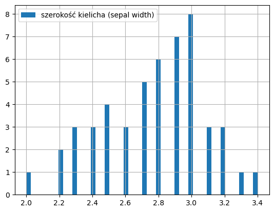

```python
Iris_versicolor_df["szerokość kielicha (sepal width)"].hist(bins=50, legend=True)
Iris_versicolor_df["szerokość kielicha (sepal width)"].describe()
```

**Wnioski cząstkowe dla serii danych 'szerokość kielicha (sepal width)'**

- **kształt rozkładu:** Mediana (2.8) jest bardzo bliska średniej (2.77), co sugeruje, że rozkład jest prawdopodobnie dość symetryczny. Różnica między kwartylami (Q3 - Q1 = 0.475) jest stosunkowo niewielka, co dodatkowo potwierdza symetrię.
- **wartości centralne:** Zarówno średnia (2.77), jak i mediana (2,8) przyjmują bardzo zbliżone wartości, co ponownie potwierdza symetrię rozkładu. Wartość centralna danych wynosi około 2.77-2.8.

Rozkład jest jednomodalny co oznacza, że istnieje jedno wyraźne skupienie wartości, czyli jeden "szczyt" w rozkładzie. Nie obserwujemy dodatkowych skupień danych.

- **rozproszenie danych** Rozproszenie danych jest stosunkowo niewielkie, co sugeruje, że większość obserwacji skupia się wokół wartości centralnej. Odchylenie standardowe (0.32) jest mniejsze niż 1, co dodatkowo potwierdza, że dane są dość ściśle skupione wokół średniej. Występuje jeden brak wartości.

```
count    50.000000
mean      4.260000
std       0.469911
min       3.000000
25%       4.000000
50%       4.350000
75%       4.600000
max       5.100000
Name: długość płatka (petal length), dtype: float64
```

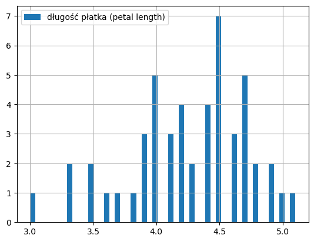

```python
Iris_versicolor_df["długość płatka (petal length)"].hist(bins=50, legend=True)
Iris_versicolor_df["długość płatka (petal length)"].describe()
```

```
count    50.000000
mean      1.326000
std       0.197753
min       1.000000
25%       1.200000
50%       1.300000
75%       1.500000
max       1.800000
Name: szerokość płatka (petal width), dtype: float64
```

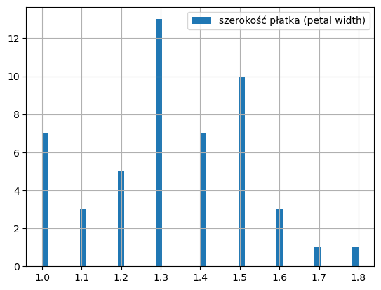

```python
Iris_versicolor_df["szerokość płatka (petal width)"].hist(bins=50, legend=True)
Iris_versicolor_df["szerokość płatka (petal width)"].describe()
```

**Wnioski cząstkowe dla serii danych 'szerokość płatka (petal width)'**

- **kształt rozkładu:** Rozkład danych jest zbliżony do symetrycznego. Różnica między średnią a medianą jest niewielka, co sugeruje, że rozkład jest w przybliżeniu symetryczny. Odległości między kwartylami są zbliżone, co dodatkowo potwierdza symetrię.
- **wartości centralne:** Średnia (1,32) oraz mediana (1,30) są do siebie bardzo zbliżone, co potwierdza symetrię rozkładu. Rozkład jednomodalny wskazuje, że istnieje jedna wartość, która występuje najczęściej.
- **rozproszenie danych** Dane są stosunkowo mało rozproszone wokół średniej. Większość wartości skupia się w niewielkim przedziale. Nie występują braki w wartościach.

- 'układ rozkładu' dla wszystkich zmiennych przyjmuje kształt symetryczny lub zbliżony do niego, co oznacza, że nie ma lub występują sporadycznie wartości, które znacząco odbiegają od większości danych.
- 'wartości centralne' dla wszystkich zmiennych nie notują znaczących odchyleń, co oznacza, że dane są dość jednorodne i skupione wokół pewnej centralnej wartości. Innymi słowy, większość obserwacji jest zbliżona do średniej, mediany lub mody.
- 'rozproszenie danych' dla wszystkich zmiennych wskazuje na niski współczynnik rozporszenia, co oznacza, że dane w zbiorze są dość jednorodne i skupione wokół pewnej wartości centralnej
- w 3 na 4 zmiennych występują luki w wartościach, w tym w 2 zmiennych są to braki pojedynczych wartości
- *Jednakże z racji na fakt iż w 'kształcie rozkładu', 'wartościach centralne' i 'rozproszeniu danych' nie wystąpują znaczące anomalie należy przyjąć, że dane w zbiorze są poprawne. Przyczyną występujących braków wartości mogą być ograniczenia skali pomiarowej oraz specyfika badanej populacji*

```python
print("\033[1mCharakterystyka przedmiotu analizy\033[0m")
Iris_versicolor_df[["długość kielicha (sepal length)", "szerokość kielicha (sepal width)", "długość płatka (petal length)", "szerokość płatka (petal width)"]].agg(["min", "max", "median"])
```

```
Charakterystyka przedmiotu analizy
```

|  | długość kielicha (sepal length) | szerokość kielicha (sepal width) | długość płatka (petal length) | szerokość płatka (petal width) |
| --- | --- | --- | --- | --- |
| min | 4.9 | 2.0 | 3.00 | 1.0 |
| max | 7.0 | 3.4 | 5.10 | 1.8 |
| median | 5.9 | 2.8 | 4.35 | 1.3 |

### Kategoria 'Iris-virginica'

```python
Iris_virginica_df = df[df["klasa (class)"] == "Iris-virginica"]
```

```
count    50.00000
mean      6.58800
std       0.63588
min       4.90000
25%       6.22500
50%       6.50000
75%       6.90000
max       7.90000
Name: długość kielicha (sepal length), dtype: float64
```

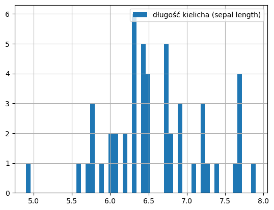

```python
Iris_virginica_df["długość kielicha (sepal length)"].hist(bins=50, legend=True)
Iris_virginica_df["długość kielicha (sepal length)"].describe()
```

**Wnioski cząstkowe dla serii danych 'długość kielicha (sepal length)'**

- **kształt rozkładu:** Rozkład zbliżony do symetrycznego. Potwierdzeniem tego są różnice między kwartylami: 75% kwartyl - 25% kwartyl = 6.9 - 6.225 = 0.675 oraz różnica między medianą a kwartylami: Mediana - 25% kwartyl = 6.5 - 6.225 = 0.275 / 75% kwartyl - Mediana = 6.9 - 6.5 = 0.4.
- **wartości centralne:** Średnia (6.59) i mediana (6.5) są do siebie bardzo zbliżone, co dodatkowo potwierdza przypuszczenie o symetrycznym rozkładzie.
- **rozproszenie danych** Dane są stosunkowo mało rozproszone, co oznacza, że większość obserwacji znajduje się w stosunkowo wąskim przedziale wartości. Występują nieregularne luki w wartościach.

```
count    50.000000
mean      2.974000
std       0.322497
min       2.200000
25%       2.800000
50%       3.000000
75%       3.175000
max       3.800000
Name: szerokość kielicha (sepal width), dtype: float64
```

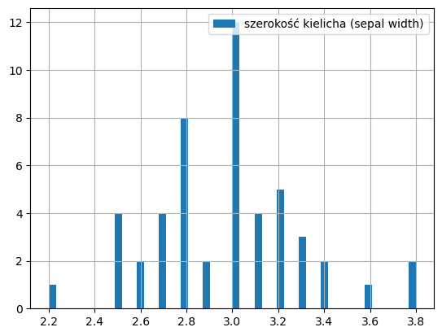

```python
Iris_virginica_df["szerokość kielicha (sepal width)"].hist(bins=50, legend=True)
Iris_virginica_df["szerokość kielicha (sepal width)"].describe()
```

**Wnioski cząstkowe dla serii danych 'szerokość kielicha (sepal width)'**

- **kształt rozkładu:** Rozkład zbliżony do symetrycznego. Średnia i mediana są do siebie bardzo zbliżone (2.97 vs 3.00), co sugeruje, że rozkład prawdopodobieństwa jest prawdopodobnie symetryczny lub lekko skośny w prawo. Odchylenie standardowe jest stosunkowo małe (0.322), co wskazuje, że większość danych skupiona jest wokół wartości średniej. Różnica między kwartylami (75% - 25% = 0.375) jest podobna do odchylenia standardowego, co dodatkowo potwierdza symetryczny charakter rozkładu.
- **wartości centralne:** Średnia (2.97) i mediana (3.00) są do siebie bardzo zbliżone, co oznacza, że większość obserwacji skupiona jest wokół wartości 3. Nie ma znaczących odchyleń od średniej.
- **rozproszenie danych** Dane są stosunkowo mało rozproszone, co sugeruje, że badana cecha jest dość jednorodna wśród obserwacji. Występują nieregularne pojedyncze luki w wartościach.

```
count    50.000000
mean      5.552000
std       0.551895
min       4.500000
25%       5.100000
50%       5.550000
75%       5.875000
max       6.900000
Name: długość płatka (petal length), dtype: float64
```

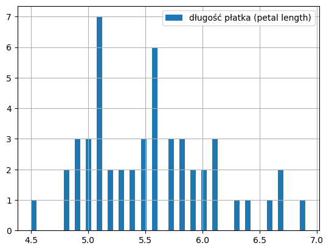

```python
Iris_virginica_df["długość płatka (petal length)"].hist(bins=50, legend=True)
Iris_virginica_df["długość płatka (petal length)"].describe()
```

**Wnioski cząstkowe dla serii danych 'długość płatka (petal length)'**

- **kształt rozkładu:** Rozkład zbliżony do symetrycznego. Średnia ≈ Mediana sugeruje, że rozkład danych jest prawdopodobnie symetryczny. Odchylenie standardowe stosunkowo małe w porównaniu do zakresu wskazuje na umiarkowane rozproszenie danych wokół średniej.
- **wartości centralne:** Brak znaczącej różnicy między średnią a medianą potwierdza symetrię rozkładu. Centralna tendencja danych koncentruje się wokół wartości 5.55.
- **rozproszenie danych** Dane są stosunkowo ściśle skupione wokół średniej, co wskazuje na niewielkie rozproszenie. Występują nieregularne pojedyncze luki w wartościach.

```
count    50.00000
mean      2.02600
std       0.27465
min       1.40000
25%       1.80000
50%       2.00000
75%       2.30000
max       2.50000
Name: szerokość płatka (petal width), dtype: float64
```

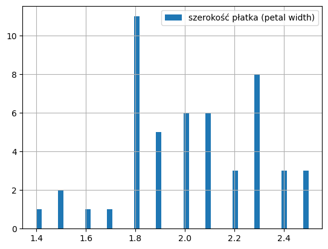

```python
Iris_virginica_df["szerokość płatka (petal width)"].hist(bins=50, legend=True)
Iris_virginica_df["szerokość płatka (petal width)"].describe()
```

**Wnioski cząstkowe dla serii danych 'szerokość płatka (petal width)'**

- **kształt rozkładu:** Rozkład zbliżony do symetrycznego. Różnica między średnią a medianą jest niewielka (2.026 - 2.0 = 0.026), co sugeruje, że rozkład jest dość symetryczny. Różnica między kwartylami (Q3 - Q1 = 2.3 - 1.8 = 0.5) jest stosunkowo niewielka, co dodatkowo potwierdza symetrię.

Odchylenie standardowe jest stosunkowo małe w porównaniu do zakresu danych, co wskazuje na niewielkie odchylenia od średniej.

- **wartości centralne:** Zarówno średnia, jak i mediana przyjmują bardzo zbliżone wartości, co ponownie potwierdza symetrię rozkładu. Wartością centralną reprezentującą ten zbiór danych jest zarówno średnia, jak i mediana.
- **rozproszenie danych** Rozproszenie danych jest niewielkie. Większość obserwacji skupiona jest w stosunkowo wąskim przedziale wokół wartości centralnej. Brak luk w wartościach.

- 'układ rozkładu' dla wszystkich zmiennych przyjmuje kształt symetryczny lub zbliżony do niego, co oznacza, że nie ma lub występują sporadycznie wartości, które znacząco odbiegają od większości danych.
- 'wartości centralne' dla wszystkich zmiennych nie notują znaczących odchyleń, co oznacza, że dane są dość jednorodne i skupione wokół pewnej centralnej wartości. Innymi słowy, większość obserwacji jest zbliżona do średniej, mediany lub mody.
- 'rozproszenie danych' dla wszystkich zmiennych wskazuje na niski współczynnik rozporszenia, co oznacza, że dane w zbiorze są dość jednorodne i skupione wokół pewnej wartości centralnej
- w 3 na 4 zmiennych występują nieregularne luki w wartościach.
- *Jednakże z racji na fakt iż w 'kształcie rozkładu', 'wartościach centralne' i 'rozproszeniu danych' nie wystąpują znaczące anomalie należy przyjąć, że dane w zbiorze są poprawne. Przyczyną występujących braków wartości może być specyfika badanej populacji*

```python
print("\033[1mCharakterystyka przedmiotu analizy\033[0m")
Iris_virginica_df[["długość kielicha (sepal length)", "szerokość kielicha (sepal width)", "długość płatka (petal length)", "szerokość płatka (petal width)"]].agg(["min", "max", "median"])
```

```
Charakterystyka przedmiotu analizy
```

|  | długość kielicha (sepal length) | szerokość kielicha (sepal width) | długość płatka (petal length) | szerokość płatka (petal width) |
| --- | --- | --- | --- | --- |
| min | 4.9 | 2.2 | 4.50 | 1.4 |
| max | 7.9 | 3.8 | 6.90 | 2.5 |
| median | 6.5 | 3.0 | 5.55 | 2.0 |

# **Transformacja danych**

**Wnioski z transformacji danych**

- Zbiór danych jest kompletny, tj. nie wykazano brakujących wartości w seriach danych.
- Występują luki w pomiarach (nie utożsamiać z brakiem danych) i zgodnie z powyższym wnioskowaniem przyczyną występujących braków wartości może być specyfika badanej populacji. Jednakże występujące luki nie wymagają uzupełnienia danych, gdyż taki proces wpłynął by na zniekształcenie wyników.

# **Analiza relacji między zmiennymi**

## Analiza serii danych

```python
# Utworzenie DataFrame'ów dla zmiennych dla kategorii 'Iris-setosa'
Iris_setosa_dlugosc_kielicha_df = Iris_setosa_df[["klasa (class)", "długość kielicha (sepal length)"]]
Iris_setosa_szerokosc_kielicha_df = Iris_setosa_df[["klasa (class)", "szerokość kielicha (sepal width)"]]
Iris_setosa_dlugosc_platka_df = Iris_setosa_df[["klasa (class)", "długość płatka (petal length)"]]
Iris_setosa_szerokosc_platka_df = Iris_setosa_df[["klasa (class)", "szerokość płatka (petal width)"]]
```

```python
# Utworzenie DataFrame'ów dla zmiennych dla kategorii 'Iris-versicolor'
Iris_versicolor_dlugosc_kielicha_df = Iris_versicolor_df[["klasa (class)", "długość kielicha (sepal length)"]]
Iris_versicolor_szerokosc_kielicha_df = Iris_versicolor_df[["klasa (class)", "szerokość kielicha (sepal width)"]]
Iris_versicolor_dlugosc_platka_df = Iris_versicolor_df[["klasa (class)", "długość płatka (petal length)"]]
Iris_versicolor_szerokosc_platka_df = Iris_versicolor_df[["klasa (class)", "szerokość płatka (petal width)"]]
```

```python
# Utworzenie DataFrame'ów dla zmiennych dla kategorii 'Iris-virginica'
Iris_virginica_dlugosc_kielicha_df = Iris_virginica_df[["klasa (class)", "długość kielicha (sepal length)"]]
Iris_virginica_szerokosc_kielicha_df = Iris_virginica_df[["klasa (class)", "szerokość kielicha (sepal width)"]]
Iris_virginica_dlugosc_platka_df = Iris_virginica_df[["klasa (class)", "długość płatka (petal length)"]]
Iris_virginica_szerokosc_platka_df = Iris_virginica_df[["klasa (class)", "szerokość płatka (petal width)"]]
```

```python
# Utworzenie DataFrame'ów dla zmiennych dla wszystkich kategorii
wg_kategorii_dlugosc_kielicha_df = pd.concat([Iris_setosa_dlugosc_kielicha_df, Iris_versicolor_dlugosc_kielicha_df, Iris_virginica_dlugosc_kielicha_df], ignore_index=True)
wg_kategorii_szerokosc_kielicha_df = pd.concat([Iris_setosa_szerokosc_kielicha_df, Iris_versicolor_szerokosc_kielicha_df, Iris_virginica_szerokosc_kielicha_df], ignore_index=True)
wg_kategorii_dlugosc_platka_df = pd.concat([Iris_setosa_dlugosc_platka_df, Iris_versicolor_dlugosc_platka_df, Iris_virginica_dlugosc_platka_df], ignore_index=True)
wg_kategorii_szerokosc_platka_df = pd.concat([Iris_setosa_szerokosc_platka_df, Iris_versicolor_szerokosc_platka_df, Iris_virginica_szerokosc_platka_df], ignore_index=True)
```

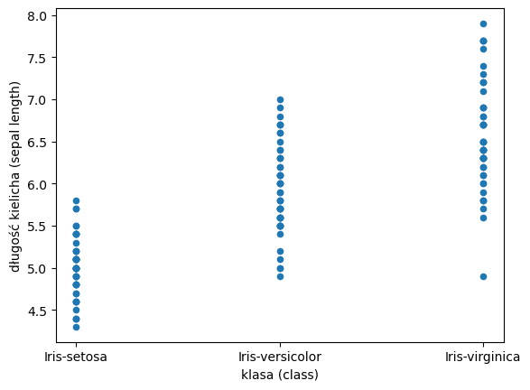

```python
# Wykres punktowy dla zmiennej 'długość kielicha (sepal length)' wg kategorii
wg_kategorii_dlugosc_kielicha_df.plot(kind="scatter", x="klasa (class)", y="długość kielicha (sepal length)")
```

**Wnioski cząstkowe dla dla zmiennej 'długość kielicha (sepal length)' wg kategorii**

- Wymiary długości kielicha 'Iris-setosa' (min 4.3 / max 5.8) są najmniejsze zarówno pod względem zakresu (1,5), jak też pod względem wymiarów wartości skrajnych
- Wymiary długości kielicha 'Iris-versicolor' (min 4.9 / max 7.0) są średnie zarówno pod względem zakresu (2.1), jak też pod względem wymiarów wartości skrajnych
- Wymiary długości kielicha 'Iris-virginica' (min 4.9 / max 7.9) są największe zarówno pod względem zakresu (3.0), jak też pod względem wymiarów wartości skrajnych

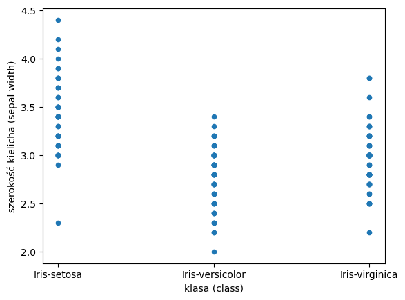

```python
# Wykres punktowy dla zmiennej 'szerokość kielicha (sepal width)' wg kategorii
wg_kategorii_szerokosc_kielicha_df.plot(kind="scatter", x="klasa (class)", y="szerokość kielicha (sepal width)")
```

**Wnioski cząstkowe dla dla zmiennej 'szerokość kielicha (sepal width)' wg kategorii**

- Wymiary szerokości kielicha 'Iris-setosa' (min 2.3 / max 4.4) są największe zarówno pod względem zakresu (2.1), jak też pod względem wymiarów wartości skrajnych
- Wymiary szerokości kielicha 'Iris-versicolor' (min 2.0 / max 3.4) są najmniejsze zarówno pod względem zakresu (1.4, jak też pod względem wymiarów wartości skrajnych
- Wymiary szerokości kielicha 'Iris-virginica' (min 2.2 / max 3.8) są średnie zarówno pod względem zakresu (1.6), jak też pod względem wymiarów wartości skrajnych

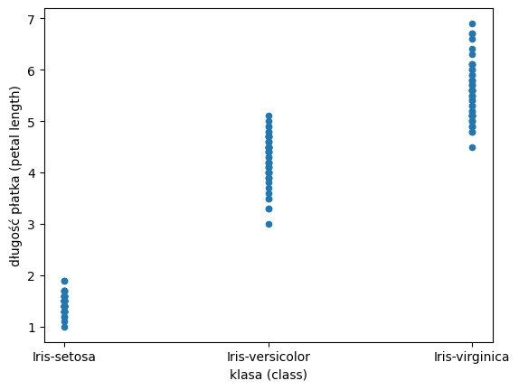

```python
# Wykres punktowy dla zmiennej 'długość płatka (petal length)' wg kategorii
wg_kategorii_dlugosc_platka_df.plot(kind="scatter", x="klasa (class)", y="długość płatka (petal length)")
```

**Wnioski cząstkowe dla dla zmiennej 'długość płatka (petal length)' wg kategorii**

- Wymiary długości płatka 'Iris-setosa' (min 1.0 / max 1.9) są najmniejsze zarówno pod względem zakresu (0.9), jak też pod względem wymiarów wartości skrajnych
- Wymiary długości płatka 'Iris-versicolor' (min 3.0 / max 5.1) są średnie zarówno pod względem zakresu (2.1), jak też pod względem wymiarów wartości skrajnych
- Wymiary długości płatka 'Iris-virginica' (min 4.5 / max 6.9) są największe zarówno pod względem zakresu (2.4), jak też pod względem wymiarów wartości skrajnych

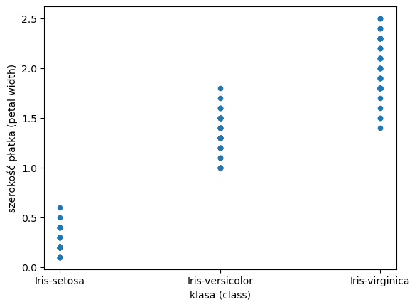

```python
# Wykres punktowy dla zmiennej 'szerokość płatka (petal width)' wg kategorii
wg_kategorii_szerokosc_platka_df.plot(kind="scatter", x="klasa (class)", y="szerokość płatka (petal width)")
```

**Wnioski cząstkowe dla dla zmiennej 'szerokość płatka (petal width)' wg kategorii**

- Wymiary szerokości płatka 'Iris-setosa' (min 0.1 / max 0.6) są najmniejsze zarówno pod względem zakresu (0.5), jak też pod względem wymiarów wartości skrajnych
- Wymiary szerokości płatka 'Iris-versicolor' (min 1.0 / max 1.8) są średnie zarówno pod względem zakresu (0.8), jak też pod względem wymiarów wartości skrajnych
- Wymiary szerokości płatka 'Iris-virginica' (min 1.4 / max 2.5) są największe zarówno pod względem zakresu (1.1), jak też pod względem wymiarów wartości skrajnych

**Wnioski z analizy serii danych**

- 'Iris-setosa' charakteryzuje się najmniejszym zakresem wartości dla zmiennych 'długość kielicha (sepal length)', 'długość płatka (petal length)' i 'szerokość płatka (petal width)'. Natomiast dla zmiennej 'szerokość kielicha (sepal width)' charakteryzuje się największym zakresem wartości. Dodatkowym elementem charakterystycznym jest fakt iż zakres zmiennych 'długość płatka (petal length)' i 'szerokość płatka (petal width)' występuje poza zakresem wartości dla pozostałych kategorii.
- 'Iris-versicolor' charakteryzuje się średnim zakresem wartości dla zmiennych 'długość kielicha (sepal length)', 'długość płatka (petal length)' i 'szerokość płatka (petal width)'. Natomiast dla zmiennej 'szerokość kielicha (sepal width)' charakteryzuje się najmniejszym zakresem wartości
- 'Iris-virginica' charakteryzuje się największym zakresem wartości dla zmiennych 'długość kielicha (sepal length)', 'długość płatka (petal length)' i 'szerokość płatka (petal width)'. Natomiast dla zmiennej 'szerokość kielicha (sepal width)' charakteryzuje się średnim zakresem wartości.

## Analiza danych wg kategorii

### Kategoria 'Iris-setosa'

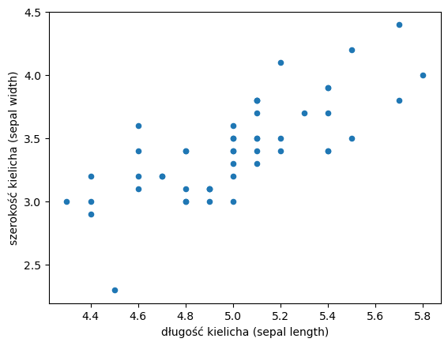

```python
# Wykres punktowy dla zmiennej 'długość kielicha (sepal length)' i 'szerokość kielicha (sepal width)' wg kategorii 'Iris-setosa'
Iris_setosa_df.plot(kind="scatter", x="długość kielicha (sepal length)", y="szerokość kielicha (sepal width)")
```

```python
# Informacje o zmiennych dla wartości 'min' / 'max' wg kategorii 'Iris-setosa'
Iris_setosa_df[["długość kielicha (sepal length)", "szerokość kielicha (sepal width)", "długość płatka (petal length)", "szerokość płatka (petal width)"]].agg(["min", "max"])
```

|  | długość kielicha (sepal length) | szerokość kielicha (sepal width) | długość płatka (petal length) | szerokość płatka (petal width) |
| --- | --- | --- | --- | --- |
| min | 4.3 | 2.3 | 1.0 | 0.1 |
| max | 5.8 | 4.4 | 1.9 | 0.6 |

```python
# Informacje o korelacji zmiennych 'długość kielicha (sepal length)', 'szerokość kielicha (sepal width)' wg kategorii 'Iris-setosa'
Iris_setosa_df[["długość kielicha (sepal length)", "szerokość kielicha (sepal width)"]].corr()
```

|  | długość kielicha (sepal length) | szerokość kielicha (sepal width) |
| --- | --- | --- |
| długość kielicha (sepal length) | 1.00000 | 0.74678 |
| szerokość kielicha (sepal width) | 0.74678 | 1.00000 |

**Wnioski cząstkowe dla korelacji parametrów kielicha dla kategorii Iris-setosa'**

- Wartość korelacji 0.74678 wskazuje na silną, dodatnią korelację.
- Istnieje wyraźny związek między długością a szerokością kielicha. Oznacza to, że te dwie cechy są ze sobą powiązane i prawdopodobnie wynikają z podobnych czynników wzrostu.

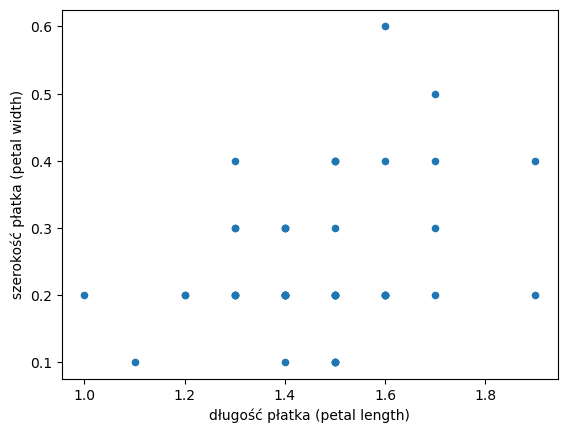

```python
# Wykres punktowy dla zmiennej 'długość płatka (petal length)' i 'szerokość płatka (petal width)' wg kategorii 'Iris-setosa'
Iris_setosa_df.plot(kind="scatter", x="długość płatka (petal length)", y="szerokość płatka (petal width)")
```

```python
# Informacje o korelacji zmiennych 'długość płatka (petal length)', 'szerokość płatka (petal width)' wg kategorii 'Iris-setosa'
Iris_setosa_df[["długość płatka (petal length)", "szerokość płatka (petal width)"]].corr()
```

|  | długość płatka (petal length) | szerokość płatka (petal width) |
| --- | --- | --- |
| długość płatka (petal length) | 1.000000 | 0.306308 |
| szerokość płatka (petal width) | 0.306308 | 1.000000 |

**Wnioski cząstkowe dla korelacji parametrów płatka dla kategorii Iris-setosa'**

- Wartość korelacji 0.306308 wskazuje na słabą, dodatnią korelację.
- Mimo że istnieje pewna zależność między długością a szerokością płatka, nie jest ona wystarczająco silna, aby mówić o wyraźnej zależności między tymi cechami.

### Kategoria 'Iris-versicolor'

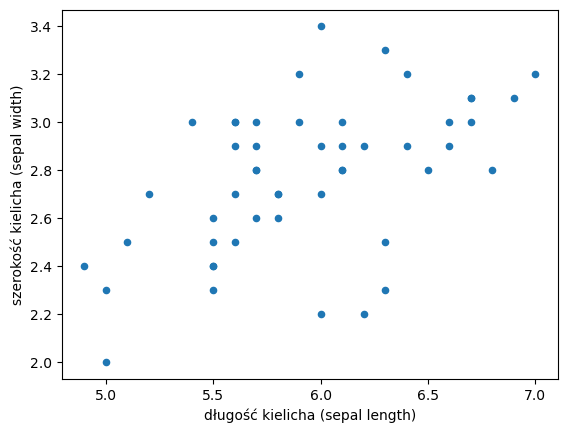

```python
# Wykres punktowy dla zmiennej 'długość kielicha (sepal length)' i 'szerokość kielicha (sepal width)' wg kategorii 'Iris-versicolor'
Iris_versicolor_df.plot(kind="scatter", x="długość kielicha (sepal length)", y="szerokość kielicha (sepal width)")
```

```python
# Informacje o zmiennych dla wartości 'min' / 'max' wg kategorii 'Iris-versicolor'
Iris_versicolor_df[["długość kielicha (sepal length)", "szerokość kielicha (sepal width)", "długość płatka (petal length)", "szerokość płatka (petal width)"]].agg(["min", "max"])
```

|  | długość kielicha (sepal length) | szerokość kielicha (sepal width) | długość płatka (petal length) | szerokość płatka (petal width) |
| --- | --- | --- | --- | --- |
| min | 4.9 | 2.0 | 3.0 | 1.0 |
| max | 7.0 | 3.4 | 5.1 | 1.8 |

```python
# Informacje o korelacji zmiennych 'długość kielicha (sepal length)', 'szerokość kielicha (sepal width)' wg kategorii 'Iris-versicolor'
Iris_versicolor_df[["długość kielicha (sepal length)", "szerokość kielicha (sepal width)"]].corr()
```

|  | długość kielicha (sepal length) | szerokość kielicha (sepal width) |
| --- | --- | --- |
| długość kielicha (sepal length) | 1.000000 | 0.525911 |
| szerokość kielicha (sepal width) | 0.525911 | 1.000000 |

**Wnioski cząstkowe dla korelacji parametrów kielicha dla kategorii Iris-versicolor'**

- Wartość korelacji 0,525911 wskazuje na umiarkowaną, dodatnią korelację.
- Istnieje związek między długością a szerokością kielicha. Oznacza to, że te dwie cechy są ze sobą powiązane i prawdopodobnie wpływają na siebie wzajemnie lub są zależne od wspólnego czynnika, czyli długość kielicha nie jest jedynym czynnikiem determinującym jego szerokość i odwrotnie.

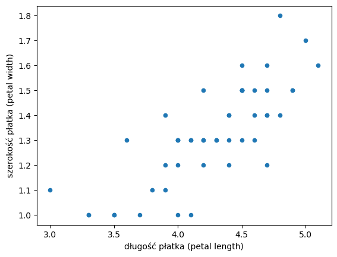

```python
# Wykres punktowy dla zmiennej 'długość płatka (petal length)' i 'szerokość płatka (petal width)' wg kategorii 'Iris-versicolor'
Iris_versicolor_df.plot(kind="scatter", x="długość płatka (petal length)", y="szerokość płatka (petal width)")
```

```python
# Informacje o korelacji zmiennych 'długość płatka (petal length)', 'szerokość płatka (petal width)' wg kategorii 'Iris-versicolor'
Iris_versicolor_df[["długość płatka (petal length)", "szerokość płatka (petal width)"]].corr()
```

|  | długość płatka (petal length) | szerokość płatka (petal width) |
| --- | --- | --- |
| długość płatka (petal length) | 1.000000 | 0.786668 |
| szerokość płatka (petal width) | 0.786668 | 1.000000 |

**Wnioski cząstkowe dla korelacji parametrów płatka dla kategorii 'Iris-versicolor'**

- Wartość korelacji 0.786668 wskazuje na silną, dodatnią korelację.
- Oznacza to, że im dłuższy jest płatek, tym szerszy jest on z dużym prawdopodobieństwem. Innymi słowy, długość i szerokość płatka są ze sobą ściśle powiązane.

### Kategoria 'Iris-virginica'

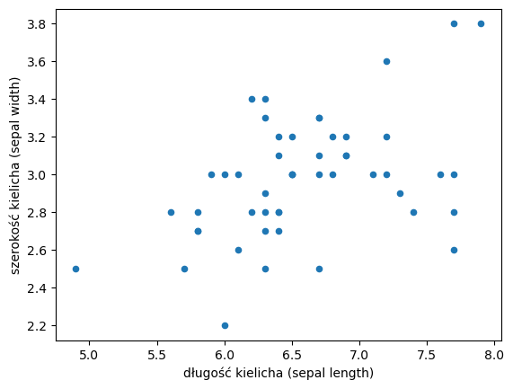

```python
# Wykres punktowy dla zmiennej 'długość kielicha (sepal length)' i 'szerokość kielicha (sepal width)' wg kategorii 'Iris-virginica'
Iris_virginica_df.plot(kind="scatter", x="długość kielicha (sepal length)", y="szerokość kielicha (sepal width)")
```

```python
# Informacje o zmiennych dla wartości 'min' / 'max' wg kategorii 'Iris-verginica'
Iris_virginica_df[["długość kielicha (sepal length)", "szerokość kielicha (sepal width)", "długość płatka (petal length)", "szerokość płatka (petal width)"]].agg(["min", "max"])
```

|  | długość kielicha (sepal length) | szerokość kielicha (sepal width) | długość płatka (petal length) | szerokość płatka (petal width) |
| --- | --- | --- | --- | --- |
| min | 4.9 | 2.2 | 4.5 | 1.4 |
| max | 7.9 | 3.8 | 6.9 | 2.5 |

```python
# Informacje o korelacji zmiennych 'długość kielicha (sepal length)', 'szerokość kielicha (sepal width)' wg kategorii 'Iris-virginica'
Iris_virginica_df[["długość kielicha (sepal length)", "szerokość kielicha (sepal width)"]].corr()
```

|  | długość kielicha (sepal length) | szerokość kielicha (sepal width) |
| --- | --- | --- |
| długość kielicha (sepal length) | 1.000000 | 0.457228 |
| szerokość kielicha (sepal width) | 0.457228 | 1.000000 |

**Wnioski cząstkowe dla korelacji parametrów kielicha dla kategorii Iris-virginica'**

- Wartość korelacji 0.457228 wskazuje na umiarkowaną, dodatnią korelację.
- Oznacza to, że wraz ze wzrostem długości kielicha, średnio wzrasta również jego szerokość.

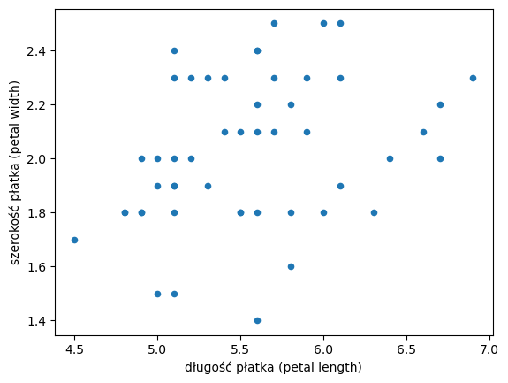

```python
# Wykres punktowy dla zmiennej 'długość płatka (petal length)' i 'szerokość płatka (petal width)' wg kategorii 'Iris-virginica'
Iris_virginica_df.plot(kind="scatter", x="długość płatka (petal length)", y="szerokość płatka (petal width)")
```

```python
# Informacje o korelacji zmiennych 'długość płatka (petal length)', 'szerokość płatka (petal width)' wg kategorii 'Iris-virginica'
Iris_virginica_df[["długość płatka (petal length)", "szerokość płatka (petal width)"]].corr()
```

|  | długość płatka (petal length) | szerokość płatka (petal width) |
| --- | --- | --- |
| długość płatka (petal length) | 1.000000 | 0.322108 |
| szerokość płatka (petal width) | 0.322108 | 1.000000 |

- Wartość korelacji 0.322108 wskazuje na słabą, dodatnią korelację.
- Oznacza to, że choć istnieje ogólna tendencja do zwiększania się szerokości wraz z długością płatka, to wiele płatków nie będzie dokładnie odpowiadało tej tendencji.

**Wnioski z analizy danych wg kategorii**

- 'Iris-setosa': Istnieje wyraźny związek między długością a szerokością kielicha. Oznacza to, że te dwie cechy są ze sobą powiązane i prawdopodobnie wynikają z podobnych czynników wzrostu. Mimo że istnieje pewna zależność między długością a szerokością płatka, nie jest ona wystarczająco silna, aby mówić o wyraźnej zależności między tymi cechami.
- 'Iris-versicolor': Istnieje związek między długością a szerokością kielicha. Oznacza to, że te dwie cechy są ze sobą powiązane i prawdopodobnie wpływają na siebie wzajemnie lub są zależne od wspólnego czynnika, czyli długość kielicha nie jest jedynym czynnikiem determinującym jego szerokość i odwrotnie. Długość i szerokość płatka są ze sobą ściśle powiązane.
- 'Iris-virginica': Istnieje związek między długością a szerokością kielicha. Oznacza to, że ze wzrostem długości kielicha, średnio wzrasta również jego szerokość. Istnieje ogólna tendencja do zwiększania się szerokości wraz z długością płatka, lecz wiele płatków nie będzie dokładnie odpowiadało tej tendencji.

# **Analiza wartości odstających**

## Analiza serii danych

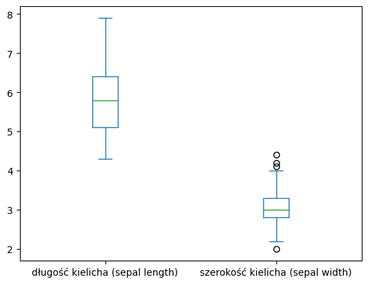

```python
# Wykres pudełkowy dla zmiennych 'długość kielicha (sepal length) i 'szerokość kielicha (sepal width)'
df[["długość kielicha (sepal length)", "szerokość kielicha (sepal width)"]].plot(kind="box")
```

**Wnioski do wykresu pudełkowego zmiennych 'długość kielicha (sepal length)' i 'szerokość kielicha (sepal width)'**

- dla zmiennej 'długość kielicha (sepal length)' brak wartości odstających
- dla zmiennej 'szerokość kielicha (sepal width)' występują wartości odstające

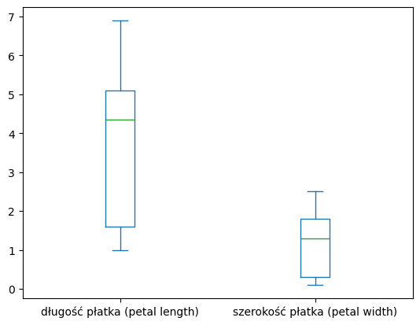

```python
# Wykres pudełkowy dla zmiennych 'długość płatka (petal length)' i 'szerokość płatka (petal width)'
df[["długość płatka (petal length)", "szerokość płatka (petal width)"]].plot(kind="box")
```

**Wnioski do wykresu pudełkowego zmiennych 'długość płatka (petal length)' i 'szerokość płatka (petal width)'**

- dla zmiennej 'długość płatka (petal length)' brak wartości odstających
- dla zmiennej 'szerokość płatka (petal width)' brak wartości odstających

## Analiza danych wg kategorii

### Kategoria 'Iris-setosa'

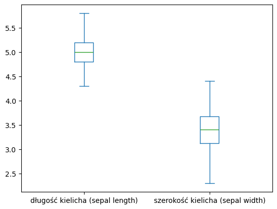

```python
# Wykres pudełkowy dla zmiennych 'długość kielicha (sepal length)' i 'szerokość kielicha (sepal width)' wg kategorii 'Iris-setosa'
Iris_setosa_df[["długość kielicha (sepal length)", "szerokość kielicha (sepal width)"]].plot(kind="box")
```

**Wnioski do wykresu pudełkowego zmiennych 'długość kielicha (sepal length)' i 'szerokość kielicha (sepal width)' wg kategorii 'Iris-setosa'**

- dla zmiennej 'długość kielicha (sepal length)' brak wartości odstających
- dla zmiennej 'szerokość kielicha (sepal width)' brak wartości odstających

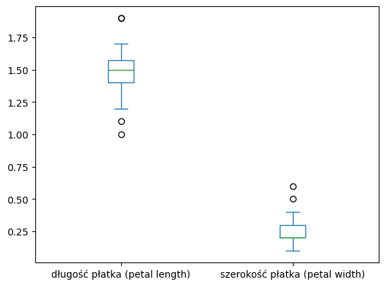

```python
# Wykres pudełkowy dla zmiennych 'długość płatka (petal length)' i 'szerokość płatka (petal width)' wg kategorii 'Iris-setosa'
Iris_setosa_df[["długość płatka (petal length)", "szerokość płatka (petal width)"]].plot(kind="box")
```

**Wnioski do wykresu pudełkowego zmiennych 'długość płatka (petal length)' i 'szerokość płatka (petal width)' wg kategorii 'Iris-setosa'**

- dla zmiennej 'długość płatka (petal length)' występują wartości odstające
- dla zmiennej 'szerokość płatka (petal width)' występują wartości odstające

### Kategoria 'Iris-versicolor'

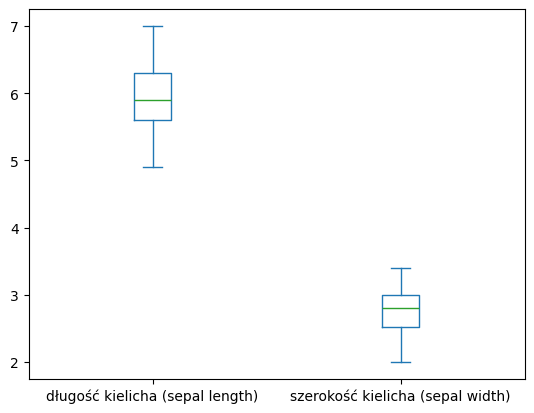

```python
# Wykres pudełkowy dla zmiennych 'długość kielicha (sepal length)' i 'szerokość kielicha (sepal width)' wg kategorii 'Iris-versicolor'
Iris_versicolor_df[["długość kielicha (sepal length)", "szerokość kielicha (sepal width)"]].plot(kind="box")
```

**Wnioski do wykresu pudełkowego zmiennych 'długość kielicha (sepal length)' i 'szerokość kielicha (sepal width)' wg kategorii 'Iris-versicolor'**

- dla zmiennej 'długość kielicha (sepal length)' brak wartości odstających
- dla zmiennej 'szerokość kielicha (sepal width)' brak wartości odstających

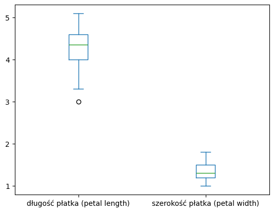

```python
# Wykres pudełkowy dla zmiennych 'długość płatka (petal length)' i 'szerokość płatka (petal width)' wg kategorii 'Iris-versicolor'
Iris_versicolor_df[["długość płatka (petal length)", "szerokość płatka (petal width)"]].plot(kind="box")
```

**Wnioski do wykresu pudełkowego zmiennych 'długość płatka (petal length)' i 'szerokość płatka (petal width)' wg kategorii 'Iris-versicolor'**

- dla zmiennej 'długość płatka (petal length)' występują wartości odstające
- dla zmiennej 'szerokość płatka (petal width)' brak wartości odstających

### Kategoria 'Iris-virginica'

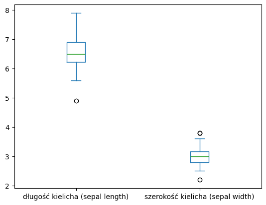

```python
# Wykres pudełkowy dla zmiennych 'długość kielicha (sepal length)' i 'szerokość kielicha (sepal width)' wg kategorii 'Iris-virginica'
Iris_virginica_df[["długość kielicha (sepal length)", "szerokość kielicha (sepal width)"]].plot(kind="box")
```

**Wnioski do wykresu pudełkowego zmiennych 'długość kielicha (sepal length)' i 'szerokość kielicha (sepal width)' wg kategorii 'Iris-virginica'**

- dla zmiennej 'długość kielicha (sepal length)' występują wartości odstające
- dla zmiennej 'szerokość kielicha (sepal width)' występują wartości odstające

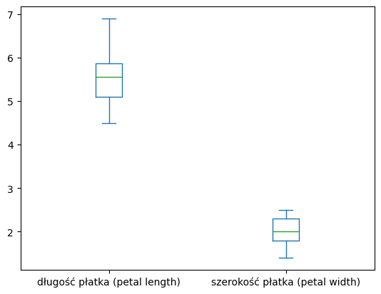

```python
# Wykres pudełkowy dla zmiennych 'długość płatka (petal length)' i 'szerokość płatka (petal width)' wg kategorii 'Iris-virginica'
Iris_virginica_df[["długość płatka (petal length)", "szerokość płatka (petal width)"]].plot(kind="box")
```

**Wnioski do wykresu pudełkowego zmiennych 'długość płatka (petal length)' i 'szerokość płatka (petal width)' wg kategorii 'Iris-virginica'**

- dla zmiennej 'długość płatka (petal length)' brak wartości odstających
- dla zmiennej 'szerokość płatka (petal width)' brak wartości odstających

# **Podsumowanie**

Wg przeprowadzonej analizy na podstawie danych 'długość płatka' i 'szerokość płatka' jest możliwe dokonanie poprawnej klasyfikacji jednej kategorii, tj. 'Iris-setosa'. Dodatkowa kategoria 'Iris-setosa' cechuje się najmniejszym zakresem wartości dla zmiennych 'długość kielicha (sepal length)', 'długość płatka (petal length)' i 'szerokość płatka (petal width)' oraz istnieniem wyraźnego związku między długością a szerokością kielicha. Natomiast klasyfikacja pozostałych kategorii zastosowaną metodologią analizy danych jest niemożliwe do dokonania z racji na fakt, iż dane w kategorii 'Iris-versicolor' i 'Iris-virginica' dla zmiennych znajdują się we wspólnym zbiorze danych bez wyraźnych cech, które mogłyby stanowić jednoznaczne różnice pomiędzy nimi.